# Practical_5_regression_2022

Soumarya Basak

14/05/2022

# Transformation Of Variable

# Problem 1

# Import the data

```r
library(readr)
library(tidyverse)
library(readxl)
```

```r
df <- read.csv("C:\\Users\\souma\\Dropbox\\Mstat_CU\\Sem 2\\Regression_analysis_1\\Data Sets\\problem_set_5_1.csv")
colnames(df) <- c("y","x")
df
```

```
##     y        x
## 1  10  50.1187
## 2  11  58.9342
## 3  16 111.4305
## 4  18 136.1330
## 5  25 237.9567
## 6  24 222.0031
## 7  26 254.3634
## 8  29 306.2504
## 9  31 343.0164
## 10 31 343.0164
## 11 34 401.3416
## 12 35 421.6146
## 13 36 442.2973
```

# Plot of the Data

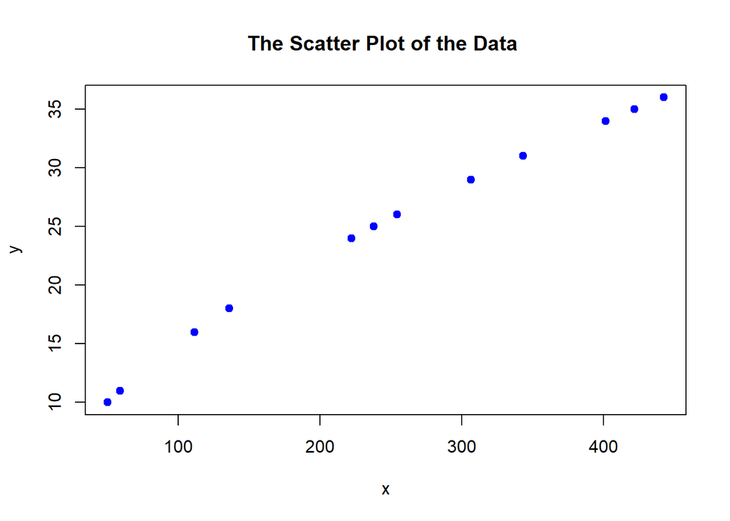

```r
plot(df$x,df$y,pch=19,col='blue',
     xlab="x",ylab = "y",
     main="The Scatter Plot of the Data ")
```

# Fit a model

```r
model1<- lm(y~x,data = df)
summary(model1)
```

```
##
## Call:
## lm(formula = y ~ x, data = df)
##
## Residuals:
##     Min      1Q  Median      3Q     Max
## -1.6455 -0.8771  0.2497  0.7440  1.1430
##
## Coefficients:
##             Estimate Std. Error t value Pr(>|t|)
## (Intercept) 8.376417   0.629721   13.30 4.01e-08 ***
## x           0.065227   0.002194   29.73 7.35e-12 ***
## ---
## Signif. codes:  0 '***' 0.001 '**' 0.01 '*' 0.05 '.' 0.1 ' ' 1
##
## Residual standard error: 1.026 on 11 degrees of freedom
## Multiple R-squared:  0.9877, Adjusted R-squared:  0.9866
## F-statistic:   884 on 1 and 11 DF,  p-value: 7.35e-12
```

**Comment:** From the above model fit we see that both the coeffecients are significant, and also the adjusted R squared is 0.98 and the residual standard error is also low, so it is a quite good fit.

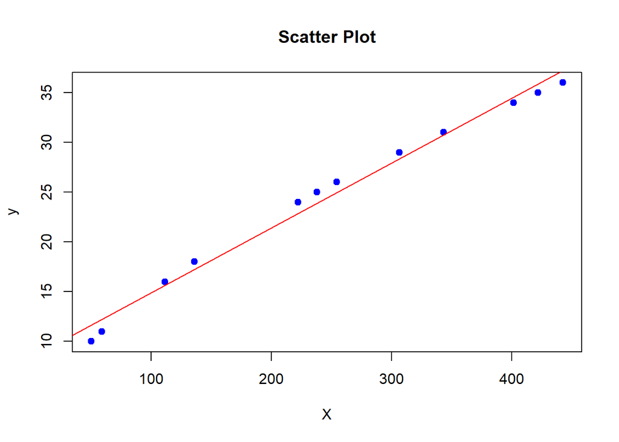

```r
plot(df$x,df$y,pch=19,col='blue',
     xlab = "X",ylab = "y",
     main = "Scatter Plot")
abline(model1, col='red')
```

From the plot we also see the plot fits well. So **I am quite satisfied**.

Although, it is a good fit, lets try a Box_Tidwell transformation,
$$x \rightarrow x^* = x^{(1/2)}$$

# Box-Tidwell transformation

This transformation makes a non-linear model to linear, here the plot is a arc of a parabolic curve, i.e. $y^2$ depends on x linearly, so we make a square root transformation.

$$x \rightarrow x^* = x^{(1/2)}$$

```r
df$x1 <- df$x^(1/2)
df
```

```
##     y        x        x1
## 1  10  50.1187  7.079456
## 2  11  58.9342  7.676861
## 3  16 111.4305 10.556065
## 4  18 136.1330 11.667605
## 5  25 237.9567 15.425845
## 6  24 222.0031 14.899768
## 7  26 254.3634 15.948774
## 8  29 306.2504 17.500011
## 9  31 343.0164 18.520702
## 10 31 343.0164 18.520702
## 11 34 401.3416 20.033512
## 12 35 421.6146 20.533256
## 13 36 442.2973 21.030865
```

Now regressing $y$ with respect to $x^{1/2}$,

```r
model2<- lm(y~x1,data = df)
summary(model2)
```

```
##
## Call:
## lm(formula = y ~ x1, data = df)
##
## Residuals:
##      Min       1Q   Median       3Q      Max
## -0.25859 -0.21765 -0.02082  0.22066  0.34613
##
## Coefficients:
##             Estimate Std. Error t value Pr(>|t|)
## (Intercept) -3.56727    0.22497  -15.86 6.34e-09 ***
## x1           1.86754    0.01406  132.83  < 2e-16 ***
## ---
## Signif. codes:  0 '***' 0.001 '**' 0.01 '*' 0.05 '.' 0.1 ' ' 1
##
## Residual standard error: 0.2311 on 11 degrees of freedom
## Multiple R-squared:  0.9994, Adjusted R-squared:  0.9993
## F-statistic: 1.764e+04 on 1 and 11 DF,  p-value: < 2.2e-16
```

For this model the coefficient are also singificant, and the Adjusted R-squared value is 0.99, which is larger than previous value and the residual standard error is also lower than the previous one. SO, the transformation more stabilizes the model.

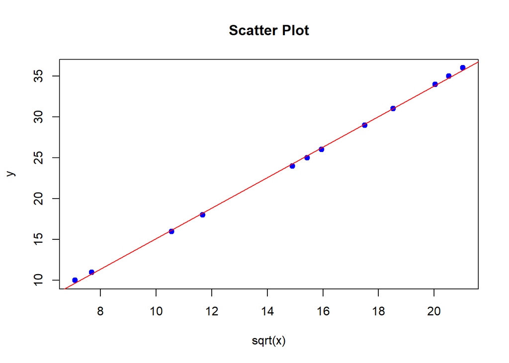

```r
plot(df$x1,df$y,pch=19,col="blue",
     xlab = "sqrt(x)",ylab = "y",main = "Scatter Plot")
abline(model2, col='red')
```

# Problem 2

## import the data

```r
df2<- read.csv("C:\\Users\\souma\\Dropbox\\Mstat_CU\\Sem 2\\Regression_analysis_1\\Data Sets\\problem_set_5_2.csv")
colnames(df2)<- c("y","x1","x2")
df2
```

```
##       y x1 x2
## 1  6.46 28 33
## 2  5.65 21 25
## 3  6.02 22 35
## 4  5.60 17 35
## 5  5.47 16 35
## 6  6.32 28 24
## 7  5.80 22 29
## 8  5.52 22 22
## 9  6.05 28 26
## 10 6.10 29 24
## 11 5.31 17 25
## 12 5.21 15 33
## 13 5.19 19 21
## 14 5.80 17 39
## 15 5.84 22 31
## 16 6.06 25 38
## 17 5.75 24 20
## 18 4.91 15 25
```

# Fit the linear Regression

```r
model3<- lm(y~ x1+x2, data = df2)
summary(model3)
```

```
##
## Call:
## lm(formula = y ~ x1 + x2, data = df2)
##
## Residuals:
##      Min       1Q   Median       3Q      Max
## -0.23721 -0.09533  0.02282  0.07600  0.20155
##
## Coefficients:
##             Estimate Std. Error t value Pr(>|t|)
## (Intercept) 3.044288   0.223767  13.605 7.64e-10 ***
## x1          0.083508   0.006377  13.096 1.30e-09 ***
## x2          0.030664   0.004999   6.135 1.91e-05 ***
## ---
## Signif. codes:  0 '***' 0.001 '**' 0.01 '*' 0.05 '.' 0.1 ' ' 1
##
## Residual standard error: 0.1213 on 15 degrees of freedom
## Multiple R-squared:  0.9234, Adjusted R-squared:  0.9132
## F-statistic:  90.4 on 2 and 15 DF,  p-value: 4.288e-09
```

# Residual Plot

```r
res<- resid(model3)

### Residual sum square

RSS <- sum(res^2)
RSS
```

```
## [1] 0.2207236
```

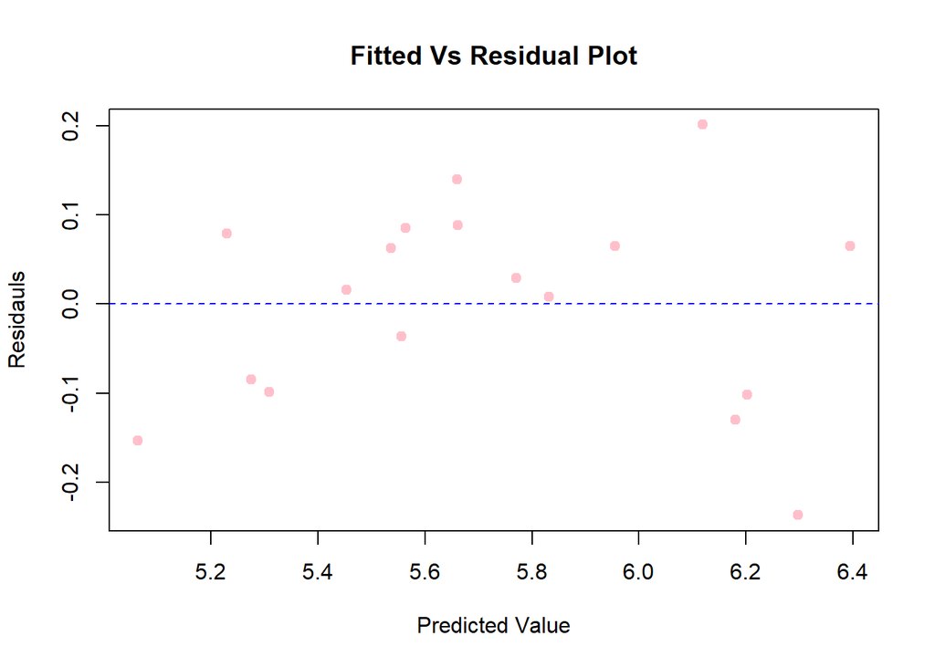

```r
plot(fitted(model3),res, pch=19,col='pink',
     xlab = "Predicted Value",ylab = "Residauls",
     main = "Fitted Vs Residual Plot")

abline(h=0, col='blue',lty=2)
```

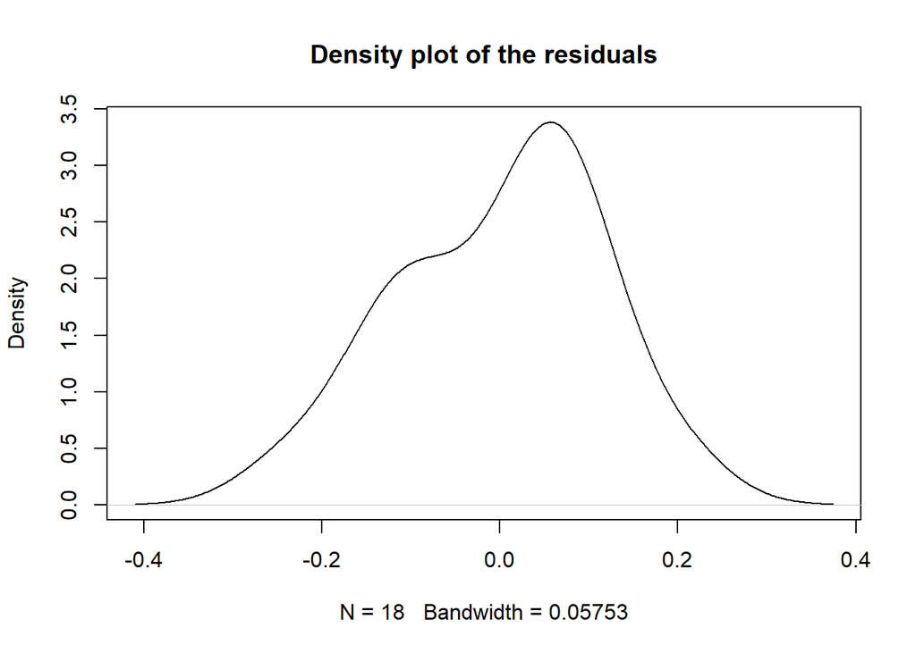

```r
plot(density(res), main = "Density plot of the residuals")
```

The variability of the model is not stabilized and also the errors doesn’t follows the assumption of normality so we need transformation of response variable.